# The economic and health cost of adverse weather events using National Weather Service storm data

Daniel Thornton

05/08/2018

## Synopsis

This report is designed to address two questions:

1. Across the United States, which types of events are most harmful with respect to population health?
2. Across the United States, which types of events have the greatest economic consequences?

The answer to these questions is based solely on an analysis and intepretation of the U.S. National Oceanic and Atmospheric Administration’s (NOAA) storm database which can be downloaded in a comma-sparated format (readable using Excel) from: https://d396qusza40orc.cloudfront.net/repdata%2Fdata%2FStormData.csv.bz2. This database tracks characteristics of major storms and weather events in the United States, including when and where they occur, as well as estimates of any fatalities, injuries, and property damage.

For further information regarding the data, see: https://d396qusza40orc.cloudfront.net/repdata%2Fpeer2_doc%2Fpd01016005curr.pdf

The report includes the R code necessary to generate the results from start to finish together with a discussion of the results.

## Data Processing

Data is downloaded from the remote server directly to the current working directory prior to loading into the R environment and processing. The data is processed to account for the units that damage to property and damage to crops is measured in i.e. K=thousands of dollars, M=millions of dollars and B=billions of dollars, therefore the cost is normalised to dollars.

```r
download.file("https://d396qusza40orc.cloudfront.net/repdata%2Fdata%2FStormData.csv.bz2","storm_data.bz2")
storm_data <- read.csv(file="storm_data.bz2")

storm_data_health <- storm_data[storm_data$FATALITIES>0,c('EVTYPE','FATALITIES','INJURIES')]
storm_data_cost <- storm_data[storm_data$FATALITIES>0,c('EVTYPE','PROPDMG','PROPDMGEXP','CROPDMG','CROPDMGEXP')]

# Replace the amount to reflect the units i.e. K = 1000s of dollars, M = millions of dollars
for (i in 1:length(storm_data_cost$PROPDMG)) {

  if (str_to_upper(storm_data_cost$PROPDMGEXP[i]) == 'K' ) {
    storm_data_cost$PROPDMG[i] = storm_data_cost$PROPDMG[i] * 1000
  } else if (str_to_upper(storm_data_cost$PROPDMGEXP[i]) == 'M') {
    storm_data_cost$PROPDMG[i] = storm_data_cost$PROPDMG[i] * 1000000
  } else if (str_to_upper(storm_data_cost$PROPDMGEXP[i]) == 'B') {
    storm_data_cost$PROPDMG[i] = storm_data_cost$PROPDMG[i] * 1000000000
  }
}

for (i in 1:length(storm_data_cost$CROPDMG)) {

  if (str_to_upper(storm_data_cost$CROPDMGEXP[i]) == 'K') {
    storm_data_cost$CROPDMG[i] = storm_data_cost$CROPDMG[i] * 1000
  } else if (str_to_upper(storm_data_cost$CROPDMGEXP[i]) == 'M') {
    storm_data_cost$CROPDMG[i] = storm_data_cost$CROPDMG[i] * 1000000
  } else if (str_to_upper(storm_data_cost$CROPDMGEXP[i]) == 'B') {
    storm_data_cost$CROPDMG[i] = storm_data_cost$CROPDMG[i] * 1000000000
  }
}
```

## Results

### Across the United States, which types of events are most harmful with respect to population health?

There are a number of aspects to consider when answering the question. The storm data carries information on the number of deaths and the number of injuries associated with an event. We can therefore use the median and maximum injuries and/or fatalities for each event type to gain an idea of the most harmful events to population level health. Most pertinent to answering the above questions is the total historic cost obtained by summing the injuries or fatalities. The report shows a stacked a bar graph in order to see the separation between fatalities and injuries and consider these in light of the question regarding ‘health’.

The top 10 events with the highest maximum injuries for a single event include the following. This gives an insight to the events that are not necessarily the most frequent, but have the most destructive capacity in a single event:

```r
fatalities_max <- aggregate(storm_data_health$FATALITIES, by=list(storm_data_health$EVTYPE), FUN=max)
colnames(fatalities_max) <- c('type','fatalities')
injuries_max <- aggregate(storm_data_health$INJURIES, by=list(storm_data_health$EVTYPE), FUN=max)
colnames(injuries_max) <- c('type','injuries')
storm_health_max <- merge(injuries_max, fatalities_max, by.x="type",by.y="type")
storm_health_max <- head(storm_health_max[order(storm_health_max$injuries,decreasing=TRUE),],n=10)
storm_health_max
```

```
##                  type injuries fatalities
## 141           TORNADO     1700        158
## 92          ICE STORM     1568          6
## 40              FLOOD      800         15
## 85  HURRICANE/TYPHOON      780         15
## 26     EXCESSIVE HEAT      519         99
## 4            BLIZZARD      385          8
## 57               HEAT      230        583
## 58          HEAT WAVE      200         33
## 143    TROPICAL STORM      200         22
## 163      WINTER STORM      165          5
```

The top 10 events with the highest median injuries for a single event include the following. This gives an insight to the events that are typically the most devastating when they occur:

```r
fatalities_median <- aggregate(storm_data_health$FATALITIES, by=list(storm_data_health$EVTYPE), FUN=median)
colnames(fatalities_median) <- c('type','fatalities')
injuries_median <- aggregate(storm_data_health$INJURIES, by=list(storm_data_health$EVTYPE), FUN=median)
colnames(injuries_median) <- c('type','injuries')
storm_health_median <- merge(injuries_median, fatalities_median, by.x="type",by.y="type")
storm_health_median <- head(storm_health_median[order(storm_health_median$injuries,decreasing=TRUE),],n=10)
storm_health_median
```

```
##                        type injuries fatalities
## 157              WILD FIRES    150.0        3.0
## 148                 TSUNAMI     64.5       16.5
## 144   TROPICAL STORM GORDON     43.0        8.0
## 155      WATERSPOUT/TORNADO     39.0        3.0
## 3                 BLACK ICE     24.0        1.0
## 27       EXCESSIVE RAINFALL     21.0        2.0
## 76       HIGH WIND AND SEAS     20.0        3.0
## 165           WINTER STORMS     17.0       10.0
## 59        HEAT WAVE DROUGHT     15.0        4.0
## 164 WINTER STORM HIGH WINDS     15.0        1.0
```

Finally the most devastating events in terms of human injuries are provided by the cumulative sum of the injuries caused by the event. These are events that have amassed the most injuries, which may be due to their common frequency or single event severity.

```r
fatalities_sum <- aggregate(storm_data_health$FATALITIES, by=list(storm_data_health$EVTYPE), FUN=sum)
colnames(fatalities_sum) <- c('type','fatalities')
injuries_sum <- aggregate(storm_data_health$INJURIES, by=list(storm_data_health$EVTYPE), FUN=sum)
colnames(injuries_sum) <- c('type','injuries')
storm_health_sum <- merge(injuries_sum, fatalities_sum, by.x="type",by.y="type")

storm_health_sum <- head(storm_health_sum[order(storm_health_sum$injuries,decreasing=TRUE),],n=20)
storm_health_sum
```

```
##                  type injuries fatalities
## 141           TORNADO    60187       5633
## 26     EXCESSIVE HEAT     4791       1903
## 40              FLOOD     2679        470
## 92          ICE STORM     1720         89
## 57               HEAT     1420        937
## 85  HURRICANE/TYPHOON     1219         64
## 4            BLIZZARD      718        101
## 97          LIGHTNING      649        816
## 145         TSTM WIND      646        504
## 35        FLASH FLOOD      641        978
## 163      WINTER STORM      599        206
## 45                FOG      308         62
## 75          HIGH WIND      308        248
## 143    TROPICAL STORM      274         58
## 58          HEAT WAVE      269        172
## 159          WILDFIRE      261         75
## 63         HEAVY SNOW      225        127
## 30       EXTREME COLD      199        160
## 166    WINTER WEATHER      187         33
## 20          DENSE FOG      157         18
```

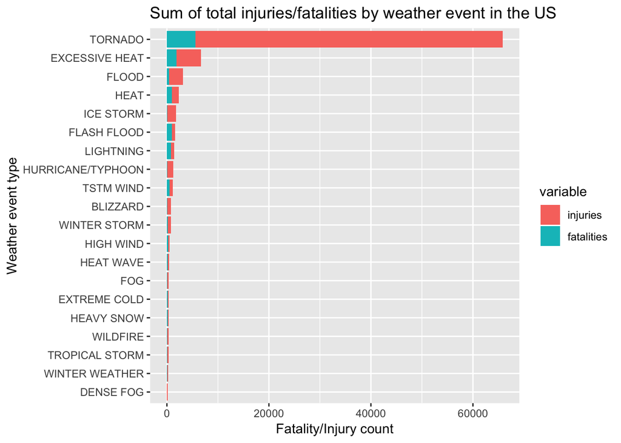

```r
storm_health_sum_melt <- melt(storm_health_sum,id.vars = "type")
ggplot(storm_health_sum_melt, aes(x = reorder(type, value), y=value, fill=variable)) + geom_col() + coord_flip() + ylab("Fatality/Injury count") + xlab("Weather event type") + ggtitle("Sum of total injuries/fatalities by weather event in the US")
```

In summary, the event with the maximum number of injuries in any single event on record was a ‘TORNADO’ event type with a total of 1700 injuries. Cumulatively, the event that has amassed the most injuries is ‘TORNADO’ event, with a total of ‘60187’ injuries. In terms of median injuries caused by events, the event with the highest median injuries has been the ‘WILD FIRES’ event with a total of ‘150’.

### Across the United States, which types of events have the greatest economic consequences?

The maximum event cost for is considered below, reporting the events with the highest one off maximum cost in terms of property damage

```r
prop_max <- aggregate(storm_data_cost$PROPDMG, by=list(storm_data_cost$EVTYPE), FUN=max)
colnames(prop_max) <- c('type','property_damage')
crop_max <- aggregate(storm_data_cost$CROPDMG, by=list(storm_data_cost$EVTYPE), FUN=max)
colnames(crop_max) <- c('type','crop_damage')
storm_cost_max <- merge(prop_max, crop_max, by.x="type",by.y="type")
storm_cost_max <- head(storm_cost_max[order(storm_cost_max$property_damage + storm_cost_max$crop_damage,decreasing=TRUE),],n=10)
storm_cost_max
```

```
##                           type property_damage crop_damage
## 85           HURRICANE/TYPHOON      1.0000e+10   1.510e+09
## 143             TROPICAL STORM      5.1500e+09   1.015e+08
## 163               WINTER STORM      5.0000e+09   5.000e+06
## 130           STORM SURGE/TIDE      4.0000e+09   0.000e+00
## 141                    TORNADO      2.8000e+09   5.000e+07
## 83              HURRICANE OPAL      2.1000e+09   5.000e+06
## 142 TORNADOES, TSTM WIND, HAIL      1.6000e+09   2.500e+06
## 40                       FLOOD      1.5000e+09   3.100e+07
## 75                   HIGH WIND      1.3000e+09   1.750e+08
## 80                   HURRICANE      7.9215e+08   4.136e+08
```

```r
prop_median <- aggregate(storm_data_cost$PROPDMG, by=list(storm_data_cost$EVTYPE), FUN=median)
colnames(prop_median) <- c('type','property_damaage')
crop_median <- aggregate(storm_data_cost$CROPDMG, by=list(storm_data_cost$EVTYPE), FUN=median)
colnames(crop_median) <- c('type','crop_damaage')
storm_cost_median <- merge(prop_median, crop_median, by.x="type",by.y="type")
storm_cost_median <- head(storm_cost_median[order(storm_cost_median$property_damaage + storm_cost_median$crop_damaage,decreasing=TRUE),],n=10)
storm_cost_median
```

```
##                           type property_damaage crop_damaage
## 130           STORM SURGE/TIDE         4.00e+09      0.0e+00
## 83              HURRICANE OPAL         2.10e+09      5.0e+06
## 142 TORNADOES, TSTM WIND, HAIL         1.60e+09      2.5e+06
## 157                 WILD FIRES         6.19e+08      0.0e+00
## 84   HURRICANE OPAL/HIGH WINDS         1.00e+08      1.0e+07
## 85           HURRICANE/TYPHOON         1.00e+08      0.0e+00
## 164    WINTER STORM HIGH WINDS         6.00e+07      5.0e+06
## 47                      FREEZE         0.00e+00      5.0e+07
## 155         WATERSPOUT/TORNADO         5.00e+07      0.0e+00
## 148                    TSUNAMI         4.20e+07      1.0e+04
```

```r
prop_sum <- aggregate(storm_data_cost$PROPDMG, by=list(storm_data_cost$EVTYPE), FUN=sum)
colnames(prop_sum) <- c('type','property_damage')
crop_sum <- aggregate(storm_data_cost$CROPDMG, by=list(storm_data_cost$EVTYPE), FUN=sum)
colnames(crop_sum) <- c('type','crop_damage')

storm_cost_sum <- merge(prop_sum, crop_sum, by.x="type",by.y="type")
storm_cost_sum <- head(storm_cost_sum[order(storm_cost_sum$property_damage + storm_cost_sum$crop_damage,decreasing=TRUE),],n=20)
storm_cost_sum
```

```
##                           type property_damage crop_damage
## 85           HURRICANE/TYPHOON     32511770000  2258120800
## 141                    TORNADO     26202300895    94825500
## 143             TROPICAL STORM      6318507000   134935000
## 40                       FLOOD      5643443000   119062500
## 163               WINTER STORM      5135062500    10020000
## 130           STORM SURGE/TIDE      4000000000           0
## 35                 FLASH FLOOD      3504340200    27555250
## 80                   HURRICANE      2063480000   897600000
## 75                   HIGH WIND      2546652425   243205100
## 159                   WILDFIRE      2504135500    75150000
## 83              HURRICANE OPAL      2100000000     5000000
## 142 TORNADOES, TSTM WIND, HAIL      1600000000     2500000
## 92                   ICE STORM       670496000    19250000
## 157                 WILD FIRES       619000000           0
## 4                     BLIZZARD       415195000   112000000
## 26              EXCESSIVE HEAT         3500000   492400000
## 145                  TSTM WIND       386168200    12103000
## 139         THUNDERSTORM WINDS       136307500    50045500
## 36           FLASH FLOOD/FLOOD       160500000      255000
## 37              FLASH FLOODING       155655000       50000
```

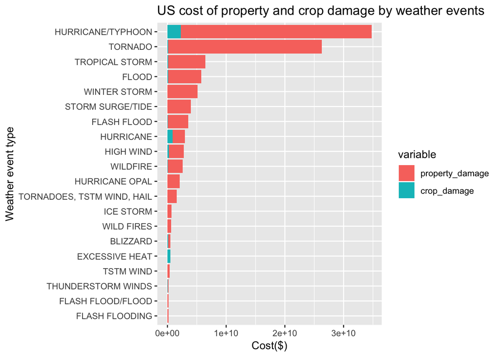

```r
storm_cost_sum_melt <- melt(storm_cost_sum,id.vars = "type")
ggplot(storm_cost_sum_melt, aes(x = reorder(type, value), y=value, fill=variable)) + geom_col() + coord_flip() + ylab("Cost($)") + xlab("Weather event type") + ggtitle("US cost of property and crop damage by weather events")
```